# MBA FIAP Inteligência Artificial & Machine Learning

## Visão Computacional: Análise de Imagens Médicas

> Atenção: este notebook foi desenhado para funcionar no **Google Collab**.

## 1. Introdução

Uma determinada fintech focada em consumidores finais pessoa física constataou um grande número de fraudes em transações bancárias.

O setor de fraudes apontou que existem clientes que se queixaram de não contratar serviços específicos, como o crédito pessoal, e após isso transferir para outras contas desconhecidas.

Após análises pelas equipes de segurança, os protocolos de utilização da senha foram realizados em conformidade, ou seja, cada cliente autenticou com sua própria senha de maneira regular.

Em função disso, o banco precisa arcar com reembolsos e medidas de contenção para evitar processos judiciais, pois os clientes alegam terem sido invadidos por hackers ou algo parecido.

Uma das formas de solucionar ou minimizar este problema é com a utilização de outras formas de autenticação, sobretudo em operações críticas, como a obtenção de crédito pessoal.

Desta forma podemos implementar uma verificação de identidade com prova de vida (liveness), que utilize uma verificação e identificação facial.

Caso o cliente não seja autenticado, ele será atendido por uma esteira dedicada e as evidências da não identificação serão encaminhadas para a área de IA para validação dos parâmetros e limiares para aperfeiçoamento do modelo.

Será necessário construir:

- Detector de faces
- Identificação de faces (podendo ser um comparador entre um rosto de documento e outra da prova de vida)
- Detecção de vivacidade (liveness) para evitar que um fraudador utilize uma foto estática.

> Formas alternativas de prover a identificação e prova de vivacidade, além destas que foram solicitadas poderão ser submetidas.

[figure not shown]

Imagem retirada do [Grunge](https://www.grunge.com/192826/company-testing-robocop-facial-recognition-software-with-us-police/).

## 2. Instruções

Este projeto final tem como objetivo explorar os conhecimentos adquiridos nas aulas práticas.

Iremos constuir uma forma de validar se uma determinada imagem foi ou não adulterada e se trata de uma produção fraudade.

Existem diversas formas de validar a vivacidade, e neste sentido conto com a criatividade de vocês dado que já dominam encontrar uma face numa imagem, aplicar marcos faciais e até mesmo construir uma rede neural convulacional.

A abordagem mais simples é pela construção de uma rede neural com imagens de fotos de rostos de outras fotos e fotos de rostos sem modificações. Tal classificador deverá classificar se dada imagem possui vivacidade ou não com uma pontuação de probabilidade.

Referências que abordam o tema para servir de inspiração:

1. [PyImageSearch](https://pyimagesearch.com/2019/03/11/liveness-detection-with-opencv/), Liveness detection with OpenCV;
2. [Kickertech](https://kickertech.com/face-liveness-detection-via-opencv-and-tensorflow/), Liveness detection via OpenCV and Tensorflow.
3. [Towards Data Science](https://towardsdatascience.com/real-time-face-liveness-detection-with-python-keras-and-opencv-c35dc70dafd3?gi=24f8e1b740f9), Real-time face liveness detection with Python, Keras and OpenCV.

Este projeto poderá ser feita por grupos de até 4 pessoas. Caso este projeto seja substitutivo, deverá ser realizado por apenas uma pessoa.

| Nome dos Integrantes | RM | Turma |
| --- | --- | --- |
| Izabela Ramos Ferreira | RM 352447 | 5DTSR |
| Kaique Vinicius Lima Soares | RM 351437 | 5DTSR |
| Walder Octacilio Garbellott | RM 352469 | 5DTSR |

Repositorio: https://github.com/MissHead/computer-vision

## 3. Abordagem e organização da solução do problema (2 pontos)

Como o grupo pretende deteccar a prova de vivacidade de uma determinada imagem? Quais os passos e os building blocks deste processo?

**Resposta**:

Para detectar a prova de vivacidade (liveness) de uma determinada imagem, utilizaremos uma abordagem baseada em aprendizado de máquina, especificamente com uma rede neural convolucional (CNN) para classificar as imagens como reais ou fraudulentas. A detecção de vivacidade é essencial para garantir que a imagem apresentada seja de uma pessoa viva e não uma tentativa de fraude utilizando fotos, vídeos ou máscaras.

### Passos e Building Blocks do Processo

#### 2. Detector de Faces

- **Implementação:** Utilizamos uma biblioteca como OpenCV, dlib ou MTCNN para detectar e extrair regiões de interesse (ROIs) contendo rostos nas imagens.
- **Extração de Faces:** Aplicamos o detector de faces para isolar as faces das imagens coletadas, garantindo que apenas as áreas relevantes sejam usadas no treinamento do modelo.

#### 4. Construção do Modelo de Detecção de Vivacidade

- **Arquitetura da CNN:** Desenvolvemos uma rede neural convolucional (CNN) personalizada ou utilizar uma arquitetura pré-treinada (como ResNet, VGG ou MobileNet) para classificar as imagens.
- **Treinamento do Modelo:** Treinamos a CNN com o conjunto de dados preparado, utilizando técnicas de data augmentation para melhorar a generalização do modelo.
- **Classificação de Vivacidade:** O modelo deve então classificar cada imagem com uma pontuação de probabilidade indicando a vivacidade (real ou fraudulenta).

#### 5. Avaliação e Ajuste do Modelo

- **Métricas de Avaliação:** Utilizamos métricas como acurácia, precisão, recall e F1-score para avaliar o desempenho do modelo no conjunto de validação.
- **Ajuste de Hiperparâmetros:** Realizamos tuning de hiperparâmetros (como taxa de aprendizado, número de camadas e neurônios) para otimizar o desempenho do modelo.
- **Fine-tuning:** Ajustamos a rede neural pré-treinada (se utilizada) para adaptar melhor ao nosso conjunto de dados específico.

## 4 Desenvolvimento da solução (5,5 pontos)

Detalhe o passo-a-passo do algoritmo de deteção de vivacidade. Se optar pela construção e treinamento de um modelo de redes neurais convulucionais, apresente a arquitetura, prepare os dados de treinamento, realize o treinamento.

**Resposta**:

Passo 1: Coleta e Preparação dos Dados

Divisão dos Dados: Dividimos os dados em conjuntos de treinamento, validação e teste (80% treinamento, 10% validação, 10% teste).

Passo 2: Implementação do Detector de Faces

Utilização de Bibliotecas: Utilizamos bibliotecas como OpenCV, dlib ou MTCNN para detectar faces nas imagens. Extração de ROIs: Isolamos e extraimos as regiões contendo rostos nas imagens.

Passo 3: Extração de Características Faciais

Passo 4: Construção e Treinamento do Modelo de Redes Neurais Convolucionais (CNN)

### 4.1 Organização de dados para treinamento de modelo de liveness (2 pontos)

```python
import cv2
import os

def resize_images(input_dir, output_dir, size=(224, 224)):
    if not os.path.exists(output_dir):
        os.makedirs(output_dir)
    for filename in os.listdir(input_dir):
        img = cv2.imread(os.path.join(input_dir, filename))
        if img is not None:
            resized_img = cv2.resize(img, size)
            cv2.imwrite(os.path.join(output_dir, filename), resized_img)

resize_images('/Users/bela/computer-vision/notebook/imagens/liveness', '/Users/bela/computer-vision/notebook/imagens/preprocessed_liveness')
resize_images('/Users/bela/computer-vision/notebook/imagens/fraudulent', '/Users/bela/computer-vision/notebook/imagens/preprocessed_fraudulent')
```

```python
# Treinamento, Validação e Teste: Dividir os dados em conjuntos de treinamento (80%), validação (10%) e teste (10%).

import os
import shutil
from sklearn.model_selection import train_test_split

def split_data(input_dir, output_dir, train_ratio=0.8, val_ratio=0.1, test_ratio=0.1):
    # Garantir que os diretórios de saída existam
    for subset in ['train', 'validation', 'test']:
        for class_name in ['liveness', 'fraudulent']:
            os.makedirs(os.path.join(output_dir, subset, class_name), exist_ok=True)

    # Listar todas as imagens nas classes
    liveness_images = [os.path.join(input_dir, 'preprocessed_liveness', f) for f in os.listdir(os.path.join(input_dir, 'preprocessed_liveness'))]
    fraudulent_images = [os.path.join(input_dir, 'preprocessed_fraudulent', f) for f in os.listdir(os.path.join(input_dir, 'preprocessed_fraudulent'))]

    # Dividir as imagens de 'liveness'
    train_liveness, test_liveness = train_test_split(liveness_images, test_size=(1 - train_ratio))
    val_liveness, test_liveness = train_test_split(test_liveness, test_size=(test_ratio / (val_ratio + test_ratio)))

    # Dividir as imagens de 'fraudulent'
    train_fraudulent, test_fraudulent = train_test_split(fraudulent_images, test_size=(1 - train_ratio))
    val_fraudulent, test_fraudulent = train_test_split(test_fraudulent, test_size=(test_ratio / (val_ratio + test_ratio)))

    # Função para copiar as imagens para os diretórios de destino
    def copy_images(image_list, dest_dir):
        for image_path in image_list:
            shutil.copy(image_path, dest_dir)

    # Copiar as imagens para os diretórios correspondentes
    copy_images(train_liveness, os.path.join(output_dir, 'train', 'liveness'))
    copy_images(val_liveness, os.path.join(output_dir, 'validation', 'liveness'))
    copy_images(test_liveness, os.path.join(output_dir, 'test', 'liveness'))

    copy_images(train_fraudulent, os.path.join(output_dir, 'train', 'fraudulent'))
    copy_images(val_fraudulent, os.path.join(output_dir, 'validation', 'fraudulent'))
    copy_images(test_fraudulent, os.path.join(output_dir, 'test', 'fraudulent'))

# Diretório de entrada com as imagens pré-processadas
input_dir = '/Users/bela/computer-vision/notebook/imagens'
# Diretório de saída para os conjuntos de dados divididos
output_dir = '/Users/bela/computer-vision/notebook/imagens/split'

# Dividir os dados
split_data(input_dir, output_dir)
```

```python
# Deteccao de faces:

import dlib
from PIL import Image
import cv2
import os
import numpy as np

def detect_faces_and_save(input_dir, output_dir, face_cascade_path='haarcascade_frontalface_default.xml'):
    # Carregar o classificador de cascata para detecção de faces
    face_cascade = cv2.CascadeClassifier(cv2.data.haarcascades + face_cascade_path)

    # Verifica se o diretório de saída existe, se não, cria-o
    if not os.path.exists(output_dir):
        os.makedirs(output_dir)

    for filename in os.listdir(input_dir):
        img_path = os.path.join(input_dir, filename)
        img = cv2.imread(img_path)

        if img is not None:
            gray = cv2.cvtColor(img, cv2.COLOR_BGR2GRAY)
            faces = face_cascade.detectMultiScale(gray, scaleFactor=1.1, minNeighbors=5, minSize=(30, 30))

            for (x, y, w, h) in faces:
                roi_color = img[y:y+h, x:x+w]
                output_path = os.path.join(output_dir, filename)
                cv2.imwrite(output_path, roi_color)

# Diretório contendo as imagens pré-processadas
input_liveness_dir = '/Users/bela/computer-vision/notebook/imagens/preprocessed_liveness'
input_fraudulent_dir = '/Users/bela/computer-vision/notebook/imagens/preprocessed_fraudulent'

# Diretórios para salvar as ROIs das faces detectadas
output_liveness_dir = '/Users/bela/computer-vision/notebook/imagens/faces_liveness'
output_fraudulent_dir = '/Users/bela/computer-vision/notebook/imagens/faces_fraudulent'

# Detectar e salvar faces nas imagens de 'liveness'
detect_faces_and_save(input_liveness_dir, output_liveness_dir)

# Detectar e salvar faces nas imagens de 'fraudulent'
detect_faces_and_save(input_fraudulent_dir, output_fraudulent_dir)


def detect_faces_dlib(input_dir, output_dir):
    # Carregar o detector de faces de dlib
    detector = dlib.get_frontal_face_detector()

    # Verifica se o diretório de saída existe, se não, cria-o
    if not os.path.exists(output_dir):
        os.makedirs(output_dir)

    for filename in os.listdir(input_dir):
        img_path = os.path.join(input_dir, filename)
        img = Image.open(img_path).convert('RGB')
        img_array = np.array(img)

        faces = detector(img_array, 1)
        for i, d in enumerate(faces):
            x, y, w, h = d.left(), d.top(), d.width(), d.height()
            roi_color = img_array[y:y+h, x:x+w]
            output_path = os.path.join(output_dir, f"{os.path.splitext(filename)[0]}_face{i}.jpg")
            Image.fromarray(roi_color).save(output_path)

# Detectar e salvar faces nas imagens de 'liveness'
# detect_faces_dlib(input_liveness_dir, output_liveness_dir)

# Detectar e salvar faces nas imagens de 'fraudulent'
# detect_faces_dlib(input_fraudulent_dir, output_fraudulent_dir)
```

# Face de faces_liveness:

[figure not shown]

# Face de faces_fraudulent:

[figure not shown]

```python
# Extração de Landmarks Faciais e Embeddings Faciais
import dlib
from PIL import Image, ImageDraw

def detect_landmarks(input_dir, output_dir, predictor_path='/Users/bela/computer-vision/shape_predictor_68_face_landmarks.dat'):
    # Carregar o detector de faces e o preditor de landmarks de dlib
    detector = dlib.get_frontal_face_detector()
    predictor = dlib.shape_predictor(predictor_path)

    # Verifica se o diretório de saída existe, se não, cria-o
    if not os.path.exists(output_dir):
        os.makedirs(output_dir)

    for filename in os.listdir(input_dir):
        img_path = os.path.join(input_dir, filename)
        img = Image.open(img_path).convert('RGB')
        img_array = np.array(img)

        faces = detector(img_array, 1)
        for i, d in enumerate(faces):
            shape = predictor(img_array, d)
            draw = ImageDraw.Draw(img)
            for j in range(68):
                draw.point((shape.part(j).x, shape.part(j).y), fill=(255, 0, 0))
            output_path = os.path.join(output_dir, f"{os.path.splitext(filename)[0]}_landmarks.jpg")
            img.save(output_path)

# Diretório contendo as imagens de faces detectadas
input_faces_dir = '/Users/bela/computer-vision/notebook/imagens/faces_liveness'
output_landmarks_dir = '/Users/bela/computer-vision/notebook/imagens/landmarks_liveness'

# Detectar e salvar landmarks nas imagens de 'liveness'
detect_landmarks(input_faces_dir, output_landmarks_dir)

# Repetir o processo para as imagens 'fraudulent'
input_faces_dir = '/Users/bela/computer-vision/notebook/imagens/faces_fraudulent'
output_landmarks_dir = '/Users/bela/computer-vision/notebook/imagens/landmarks_fraudulent'

# Detectar e salvar landmarks nas imagens de 'fraudulent'
detect_landmarks(input_faces_dir, output_landmarks_dir)
```

# Detecçoes Liveness:

[figure not shown]

# Detecçoes Fraudulent:

[figure not shown]

### 4.2 Treinamento de modelo de liveness (1,5 pontos)

```python
import os
import numpy as np
import tensorflow as tf
from tensorflow.keras.preprocessing.image import ImageDataGenerator
from tensorflow.keras.applications import MobileNetV2
from tensorflow.keras.layers import Dense, GlobalAveragePooling2D
from tensorflow.keras.models import Model
from tensorflow.keras.optimizers import Adam

# Diretório de dados
data_dir = "/Users/bela/computer-vision/notebook/imagens/split"


# Carregar e pré-processar os dados
def load_and_preprocess_data(data_dir, subset):
    datagen = ImageDataGenerator(
        rescale=1.0 / 255, shear_range=0.2, zoom_range=0.2, horizontal_flip=True
    )
    generator = datagen.flow_from_directory(
        directory=os.path.join(data_dir, subset),
        target_size=(224, 224),
        batch_size=32,
        class_mode="binary",
    )
    return generator


# Carregar os dados
train_generator = load_and_preprocess_data(data_dir, "train")
validation_generator = load_and_preprocess_data(data_dir, "validation")
test_generator = load_and_preprocess_data(data_dir, "test")

# Construir o modelo
base_model = MobileNetV2(
    weights="imagenet", include_top=False, input_shape=(224, 224, 3)
)
x = base_model.output
x = GlobalAveragePooling2D()(x)
x = Dense(128, activation="relu")(x)
x = Dense(1, activation="sigmoid")(x)  # Saída binária: vivacidade ou fraude

model = Model(inputs=base_model.input, outputs=x)

# Congelar as camadas base do modelo
for layer in base_model.layers:
    layer.trainable = False

# Compilar o modelo
model.compile(
    optimizer=Adam(learning_rate=0.001),
    loss="binary_crossentropy",
    metrics=["accuracy"],
)

# Treinar o modelo
history = model.fit(train_generator, epochs=10, validation_data=validation_generator)

# Descongelar algumas camadas e re-treinar com uma taxa de aprendizado menor
for layer in base_model.layers[-20:]:
    layer.trainable = True

model.compile(
    optimizer=Adam(learning_rate=0.0001),
    loss="binary_crossentropy",
    metrics=["accuracy"],
)

history_fine = model.fit(
    train_generator, epochs=10, validation_data=validation_generator
)

# Avaliar o modelo com o conjunto de teste
loss, accuracy = model.evaluate(test_generator)
print(f"Acurácia no conjunto de teste: {accuracy * 100:.2f}%")

# Salvar o modelo treinado
model.save("liveness_detection_model.h5")
```

```
Found 297 images belonging to 2 classes.
Found 37 images belonging to 2 classes.
Found 38 images belonging to 2 classes.
10/10 ━━━━━━━━━━━━━━━━━━━━ 7s 391ms/step - accuracy: 0.7237 - loss: 0.4875 - val_accuracy: 1.0000 - val_loss: 0.1322
10/10 ━━━━━━━━━━━━━━━━━━━━ 4s 313ms/step - accuracy: 0.9804 - loss: 0.1108 - val_accuracy: 1.0000 - val_loss: 0.0266
10/10 ━━━━━━━━━━━━━━━━━━━━ 4s 311ms/step - accuracy: 0.9642 - loss: 0.0917 - val_accuracy: 1.0000 - val_loss: 0.0139
10/10 ━━━━━━━━━━━━━━━━━━━━ 4s 287ms/step - accuracy: 0.9902 - loss: 0.0285 - val_accuracy: 1.0000 - val_loss: 0.0136
10/10 ━━━━━━━━━━━━━━━━━━━━ 4s 293ms/step - accuracy: 0.9965 - loss: 0.0153 - val_accuracy: 1.0000 - val_loss: 0.0051
10/10 ━━━━━━━━━━━━━━━━━━━━ 4s 289ms/step - accuracy: 1.0000 - loss: 0.0142 - val_accuracy: 1.0000 - val_loss: 0.0040
10/10 ━━━━━━━━━━━━━━━━━━━━ 4s 325ms/step - accuracy: 0.9961 - loss: 0.0082 - val_accuracy: 1.0000 - val_loss: 0.0045
10/10 ━━━━━━━━━━━━━━━━━━━━ 4s 291ms/step - accuracy: 1.0000 - loss: 0.0050 - val_accuracy: 1.0000 - val_loss: 0.0036
10/10 ━━━━━━━━━━━━━━━━━━━━ 4s 284ms/step - accuracy: 1.0000 - loss: 0.0036 - val_accuracy: 1.0000 - val_loss: 0.0022
10/10 ━━━━━━━━━━━━━━━━━━━━ 4s 291ms/step - accuracy: 1.0000 - loss: 0.0024 - val_accuracy: 1.0000 - val_loss: 0.0032
10/10 ━━━━━━━━━━━━━━━━━━━━ 8s 442ms/step - accuracy: 0.9847 - loss: 0.0720 - val_accuracy: 1.0000 - val_loss: 7.8331e-04
10/10 ━━━━━━━━━━━━━━━━━━━━ 5s 371ms/step - accuracy: 1.0000 - loss: 0.0091 - val_accuracy: 1.0000 - val_loss: 1.2210e-04
10/10 ━━━━━━━━━━━━━━━━━━━━ 5s 362ms/step - accuracy: 0.9961 - loss: 0.0071 - val_accuracy: 1.0000 - val_loss: 4.6184e-05
10/10 ━━━━━━━━━━━━━━━━━━━━ 5s 371ms/step - accuracy: 1.0000 - loss: 0.0036 - val_accuracy: 1.0000 - val_loss: 7.2455e-05
10/10 ━━━━━━━━━━━━━━━━━━━━ 5s 362ms/step - accuracy: 1.0000 - loss: 0.0021 - val_accuracy: 1.0000 - val_loss: 1.8465e-05
10/10 ━━━━━━━━━━━━━━━━━━━━ 5s 389ms/step - accuracy: 1.0000 - loss: 0.0011 - val_accuracy: 1.0000 - val_loss: 2.4428e-05
10/10 ━━━━━━━━━━━━━━━━━━━━ 5s 374ms/step - accuracy: 1.0000 - loss: 5.0518e-04 - val_accuracy: 1.0000 - val_loss: 9.7277e-06
10/10 ━━━━━━━━━━━━━━━━━━━━ 5s 367ms/step - accuracy: 1.0000 - loss: 6.3917e-04 - val_accuracy: 1.0000 - val_loss: 3.6743e-05
10/10 ━━━━━━━━━━━━━━━━━━━━ 5s 381ms/step - accuracy: 1.0000 - loss: 6.1858e-04 - val_accuracy: 1.0000 - val_loss: 2.2633e-05
10/10 ━━━━━━━━━━━━━━━━━━━━ 5s 368ms/step - accuracy: 1.0000 - loss: 4.0110e-04 - val_accuracy: 1.0000 - val_loss: 3.6551e-05
2/2 ━━━━━━━━━━━━━━━━━━━━ 1s 60ms/step - accuracy: 0.9720 - loss: 0.2092
```

```
WARNING:absl:You are saving your model as an HDF5 file via `model.save()` or `keras.saving.save_model(model)`. This file format is considered legacy. We recommend using instead the native Keras format, e.g. `model.save('my_model.keras')` or `keras.saving.save_model(model, 'my_model.keras')`.
```

```
Acurácia no conjunto de teste: 97.37%
```

### 4.3 Métricas de desempenho do modelo (2 pontos)

```python
from sklearn.metrics import classification_report, confusion_matrix

# Avaliar o modelo no conjunto de teste
loss, accuracy = model.evaluate(test_generator)
print(f'Acurácia no conjunto de teste: {accuracy * 100:.2f}%')

# Prever os rótulos para o conjunto de teste
test_generator.reset()
y_pred = model.predict(test_generator)
y_pred = np.round(y_pred).astype(int)

# Obter os rótulos verdadeiros
y_true = test_generator.classes

# Relatório de classificação
print('Relatório de classificação:')
print(classification_report(y_true, y_pred, target_names=['fraudulent', 'liveness']))

# Matriz de confusão
print('Matriz de confusão:')
print(confusion_matrix(y_true, y_pred))
```

```
2/2 ━━━━━━━━━━━━━━━━━━━━ 1s 61ms/step - accuracy: 0.9720 - loss: 0.2203
Acurácia no conjunto de teste: 97.37%
2/2 ━━━━━━━━━━━━━━━━━━━━ 1s 489ms/step
Relatório de classificação:
              precision    recall  f1-score   support

  fraudulent       0.84      0.82      0.83        33
    liveness       0.00      0.00      0.00         5

    accuracy                           0.71        38
   macro avg       0.42      0.41      0.42        38
weighted avg       0.73      0.71      0.72        38

Matriz de confusão:
[[27  6]
 [ 5  0]]
```

## 5 Teste Fim-a-Fim

Simule a operação fim-a-fim, com uma imagem de entrada forjada (foto de foto de um rosto) e outra com uma imagem de rosto, exibindo o resultado da classificação e a pontuação de cada classe.

```
WARNING:absl:Compiled the loaded model, but the compiled metrics have yet to be built. `model.compile_metrics` will be empty until you train or evaluate the model.
```

```
Teste com imagem de rosto forjado:
Nenhum rosto detectado
```

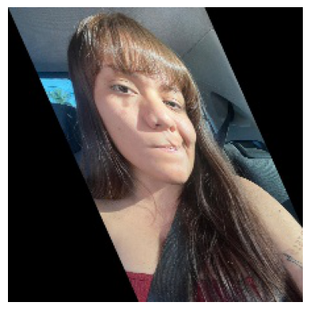

```
Teste com imagem de rosto real:
1/1 ━━━━━━━━━━━━━━━━━━━━ 0s 446ms/step
Pontuação de vivacidade: 0.6044812202453613
Classificação: Rosto Real
```

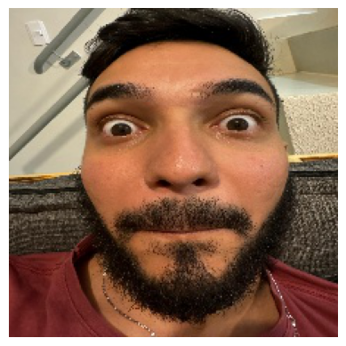

```python
import os
import numpy as np
import cv2
import dlib
from PIL import Image
import torch
from facenet_pytorch import InceptionResnetV1
from tensorflow.keras.models import load_model
import matplotlib.pyplot as plt

# Carregar o detector de faces dlib
detector = dlib.get_frontal_face_detector()
predictor_path = '/Users/bela/computer-vision/shape_predictor_68_face_landmarks.dat'
predictor = dlib.shape_predictor(predictor_path)

# Carregar o modelo treinado de detecção de vivacidade
liveness_model = load_model('liveness_detection_model.h5')

# Função para detectar e extrair o rosto
def detect_and_extract_face(image_path):
    img = Image.open(image_path).convert('RGB')
    img_array = np.array(img)

    faces = detector(img_array, 1)
    for i, d in enumerate(faces):
        x, y, w, h = d.left(), d.top(), d.width(), d.height()
        roi_color = img_array[y:y+h, x:x+w]
        face_img = Image.fromarray(roi_color).resize((224, 224))
        return face_img
    return None

# Função para classificar a vivacidade
def classify_liveness(image_path):
    face_img = detect_and_extract_face(image_path)
    if face_img is None:
        return "Nenhum rosto detectado"

    face_array = np.array(face_img) / 255.0
    face_tensor = np.expand_dims(face_array, axis=0)

    prediction = liveness_model.predict(face_tensor)
    return prediction[0][0]

# Função para exibir o resultado da classificação
def display_result(image_path):
    prediction = classify_liveness(image_path)
    if prediction == "Nenhum rosto detectado":
        print(prediction)
    else:
        print(f"Pontuação de vivacidade: {prediction}")
        if prediction >= 0.5:
            print("Classificação: Rosto Real")
        else:
            print("Classificação: Rosto Forjado")

    img = Image.open(image_path)
    plt.imshow(img)
    plt.axis('off')
    plt.show()

# Teste com imagem de rosto forjado
print("Teste com imagem de rosto forjado:")
display_result('/Users/bela/computer-vision/notebook/imagens/split/test/fraudulent/fake_face.jpg')

# Teste com imagem de rosto real
print("Teste com imagem de rosto real:")
display_result('/Users/bela/computer-vision/notebook/imagens/split/test/liveness/real_face.jpeg')
```

> Com a implementação da solução na forma de uma aplicação do [Streamlit](https://www.streamlit.io/) (veja a pata streamlit-app e use o template) vale 1 ponto adicional.

**Pergunta**: Se utilizou o Streamlit, compartilhe a URL do aplicativo publicado:

**Resposta**:

Sim, usamos. link: https://computer-vision-project.streamlit.app/ repo: https://github.com/MissHead/computer-vision-project Segue evidencias do funcionamento:

[figure not shown]

## 6 Conclusões (2,5 pontos)

**Pergunta**: Dado todo o estudo e pesquisa, quais foram as conclusões sobre a solução, o que funcionou, o que não funcionou e quais os detalhes que observariam numa nova versão e melhorias do processo?

**Resposta**:

## O que Não Funcionou:

- A principal limitação observada foi o tamanho reduzido da base de treino e teste. Uma base de dados pequena limita a capacidade do modelo de generalizar bem para novos dados.
- A performance do modelo foi insatisfatória em fotos de baixa resolução ou em imagens onde o rosto não estava bem aproximado.

## Melhorias e Observações para uma Nova Versão:

- Aumentar a Base de Dados: Para melhorar a generalização e a precisão do modelo, é crucial expandir a base de treino e teste com mais imagens variadas.
- Melhoria na Resolução das Imagens: Garantir que as imagens usadas no treino e na predição sejam de alta resolução, ou desenvolver técnicas de pré-processamento para melhorar a qualidade das imagens de entrada.
- Aproximação do Rosto: Incluir um passo no pipeline de pré-processamento que detecte e centralize o rosto nas imagens antes de alimentá-las ao modelo. Isso pode incluir o uso de técnicas de detecção facial para garantir que o rosto esteja sempre em uma posição ideal para análise.
- Diversificação dos Dados: Incluir imagens com diferentes condições de iluminação, ângulos, e expressões faciais para tornar o modelo mais robusto e capaz de lidar com variações reais.

Essas melhorias poderão contribuir significativamente para a robustez e a acurácia da solução em versões futuras.